# Concrete Compressive Strength Prediction

### Submitted by - Dr. Mugdha Dongre

## Table of Content

1. Company Introduction
2. Problem Statement
3. Libraries
   - 3.1 Importing Libraries
4. Data Acquisition & Descriptions
   - 4.1 Data Description
   - 4.2 Data Information
5. Exploratory Data Analysis
6. Data Post-processing
   - 6.1 Handling Categorical columns
   - 6.2 Feature Extraction
   - 6.3 Splitting the Dataset
   - 6.4 Scaling
7. Model Selection
   - 7.1 Linear Regression
   - 7.2 Decision Tree
   - 7.3 Random Forest
   - 7.4 Boosting: XG Boost
   - 7.5 Boosting: Gradient Boost
   - 7.6 Boosting: ADA Boost
   - 7.7 KNN
   - 7.8 Cross Validation
8. Analysis of Test dataset
   - 8.1 Getting Information about dataset
   - 8.2 Scaling (Test dataset)
   - 8.3 Prediction of Comporessive Strength
   - 8.4 Preparing Submission file
   - 8.5 Saving C.S. values to Excel sheet

## 1. Company Inroduction

### Plastion is a major Concrete Producer.

Their concrete stands out to be one of the best in the business and holds a contract with five of the most well known real estate companies.

Recently, they have developed a new kind of concrete which requires less water and is stronger and better than the concrete they used to sell.

They have few competitors who are also developing new kinds of concrete to launch in the market to get more clients.

### Current Scenario

The regular price of concrete per cubic yard is around $100 to $200 but due to market inflation the current price has gone down and the company is at loss.

The company has developed a new concrete solution which can be a potential game-changer for the company in the market but they are not sure about the concrete compressive strength which is a very important factor for concrete sale

# 2. Problem Definition

### The current process suffers from the following problems:

- The company is under a time crunch to test the compressive strength of the concrete to release in the market.
- They were using manual methods to test the compressive strength of the concrete which is very time-consuming and inefficient.
- The company has hired you as a data science consultant.
- They want to automate the process of accurately identifying the compressive strength of the concrete, based on the materials used.

## 3. Libraries

### 3.1 Importing Libraries

```python
!pip install -q pandas-profiling                                    # Library to generate basic statistics about data
# Importing Libraries #
import numpy as np
import pandas as pd
import matplotlib
import matplotlib.pyplot as plt
import seaborn as sns
%matplotlib inline
import warnings
warnings.filterwarnings('ignore')
warnings.warn("this will not show")
```

[output not shown]

## 4. Data Acquisition & Description

The dataset is divided into two parts:

**Train Set:**

| Records | Features | Target Variable |
| --- | --- | --- |
| 824 | 10 | Compressive Strength (MPa) |

**Test Set:**

| Records | Features | Predicted Variable |
| --- | --- | --- |
| 206 | 9 | Compressive Strength (MPa) |

**The model developmet for csMPa prediction will be done in Jupyter Notebook.**

| Id | Feature | Description |
| --- | --- | --- |
| 01 | ID | Unique identity of each observation. |
| 02 | cement | Quantity of cement in the mixture in kg(kilogram). |
| 03 | slag | Quantity of cement in the mixture in kg(kilogram). |
| 04 | Flyash | Quantity of fly ash in the mixture in kg(kilogram). |
| 05 | water | Quantity of water in the mixture in kg(kilogram). |
| 06 | superplasticizer | Quantity of superplasticizer in the mixture in kg(kilogram). |
| 07 | coarseaggregate | Quantity of coarse aggregate in the mixture in kg(kilogram). |
| 08 | fineaggregate | Quantity of fine aggregate in the mixture in kg(kilogram). |
| 09 | age | Age of the mixture in days. |
| 10 | csMPa | compressive strength of concrete in MPa(dependent variable) |

```python
# Loading the Train dataset #
missing_value = ['n.a','?','na','NA']                    # Data file contains values with '?' sign
data_trn = pd.read_csv(r'E:\INSAID Projects\Concrete compressive strength\concrete_train.csv', na_values = missing_value)
print('Data Shape of Training Data: ', data_trn.shape)
data_trn.head()
```

```
Data Shape of Training Data:  (824, 10)
```

|  | Id | cement | slag | flyash | water | superplasticizer | coarseaggregate | fineaggregate | age | csMPa |
| --- | --- | --- | --- | --- | --- | --- | --- | --- | --- | --- |
| 0 | 995 | 158.6 | 148.9 | 116.0 | 175.1 | 15.0 | 953.3 | 719.7 | 28 | 27.68 |
| 1 | 507 | 424.0 | 22.0 | 132.0 | 178.0 | 8.5 | 822.0 | 750.0 | 28 | 62.05 |
| 2 | 334 | 275.1 | 0.0 | 121.4 | 159.5 | 9.9 | 1053.6 | 777.5 | 3 | 23.80 |
| 3 | 848 | 252.0 | 97.0 | 76.0 | 194.0 | 8.0 | 835.0 | 821.0 | 28 | 33.40 |
| 4 | 294 | 168.9 | 42.2 | 124.3 | 158.3 | 10.8 | 1080.8 | 796.2 | 3 | 7.40 |

### 4.1 Data Description

```python
data_trn.describe()
```

|  | Id | cement | slag | flyash | water | superplasticizer | coarseaggregate | fineaggregate | age | csMPa |
| --- | --- | --- | --- | --- | --- | --- | --- | --- | --- | --- |
| count | 824.000000 | 824.000000 | 824.000000 | 824.000000 | 824.000000 | 824.000000 | 824.000000 | 824.000000 | 824.000000 | 824.000000 |
| mean | 513.847087 | 283.360801 | 74.371602 | 53.160801 | 181.797087 | 6.163956 | 973.548544 | 772.107403 | 44.661408 | 35.857864 |
| std | 296.786779 | 107.536404 | 86.977784 | 64.000646 | 21.321905 | 5.967258 | 78.694630 | 80.984717 | 60.475702 | 16.865099 |
| min | 0.000000 | 102.000000 | 0.000000 | 0.000000 | 121.800000 | 0.000000 | 801.000000 | 594.000000 | 1.000000 | 2.330000 |
| 25% | 251.750000 | 192.000000 | 0.000000 | 0.000000 | 164.900000 | 0.000000 | 932.000000 | 726.775000 | 12.250000 | 23.685000 |
| 50% | 513.500000 | 275.100000 | 22.000000 | 0.000000 | 185.350000 | 6.100000 | 968.000000 | 778.500000 | 28.000000 | 34.080000 |
| 75% | 770.250000 | 359.900000 | 144.775000 | 118.300000 | 192.000000 | 10.125000 | 1040.600000 | 821.250000 | 56.000000 | 45.862500 |
| max | 1028.000000 | 540.000000 | 359.400000 | 195.000000 | 247.000000 | 32.200000 | 1145.000000 | 992.600000 | 365.000000 | 82.600000 |

### 4.2 Data Information

```python
data_trn.info()
```

```
<class 'pandas.core.frame.DataFrame'>
RangeIndex: 824 entries, 0 to 823
Data columns (total 10 columns):
 #   Column            Non-Null Count  Dtype
---  ------            --------------  -----
 0   Id                824 non-null    int64
 1   cement            824 non-null    float64
 2   slag              824 non-null    float64
 3   flyash            824 non-null    float64
 4   water             824 non-null    float64
 5   superplasticizer  824 non-null    float64
 6   coarseaggregate   824 non-null    float64
 7   fineaggregate     824 non-null    float64
 8   age               824 non-null    int64
 9   csMPa             824 non-null    float64
dtypes: float64(8), int64(2)
memory usage: 64.5 KB
```

```python
# Handling Duplicate data
print('Contains Duplicate Rows?',data_trn.duplicated().any())
```

```
Contains Duplicate Rows? False
```

## Observations:

- The dataset is clean (no missing and duplicated values

## 5. Exploratory Data Analysis

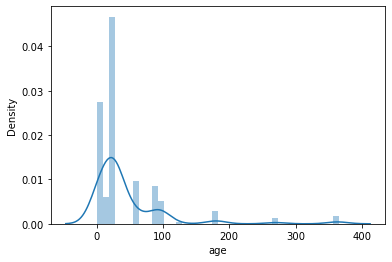

```python
sns.distplot(data_trn['age'])
```

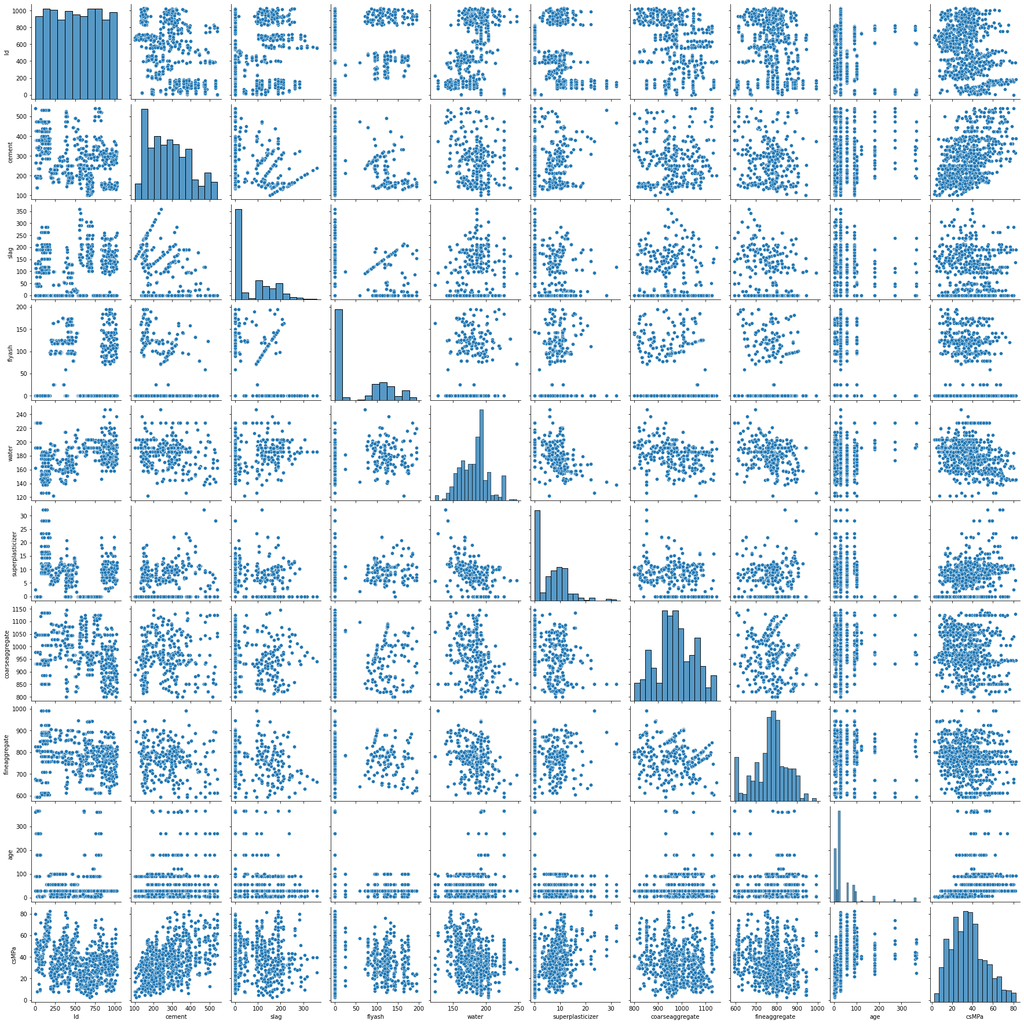

```python
sns.pairplot(data_trn)
```

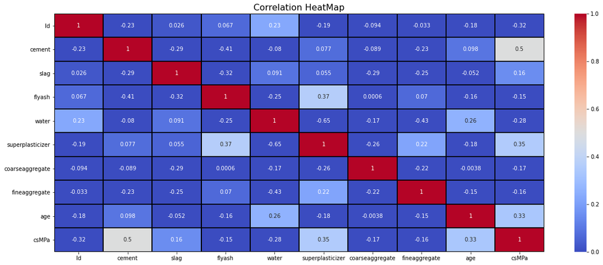

```python
figure = plt.figure(figsize = (20,8))
HeatMap = sns.heatmap(data_trn.corr(),annot = True,cmap = 'coolwarm',vmin = 0, vmax = 1,linecolor = 'black',linewidths = 1)
HeatMap.set_title('Correlation HeatMap', fontdict = {'fontsize':16})
```

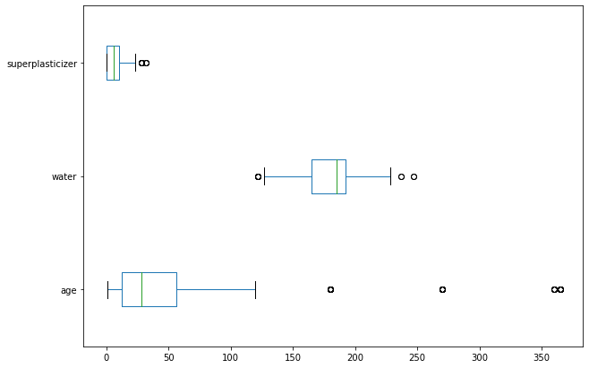

```python
data_trn[['age','water','superplasticizer']].plot(kind='box', figsize=(10, 7), vert=False)
```

## 6. Data Post-processing

- **Machine Learning Algorithm** works with **numerical** values.
- So, it is necessary to **convert the categorical columns into Numerical columns.**

### 6.1 Handling Categorical columns

```python
data_trn.info()
```

```
<class 'pandas.core.frame.DataFrame'>
RangeIndex: 824 entries, 0 to 823
Data columns (total 10 columns):
 #   Column            Non-Null Count  Dtype
---  ------            --------------  -----
 0   Id                824 non-null    int64
 1   cement            824 non-null    float64
 2   slag              824 non-null    float64
 3   flyash            824 non-null    float64
 4   water             824 non-null    float64
 5   superplasticizer  824 non-null    float64
 6   coarseaggregate   824 non-null    float64
 7   fineaggregate     824 non-null    float64
 8   age               824 non-null    int64
 9   csMPa             824 non-null    float64
dtypes: float64(8), int64(2)
memory usage: 64.5 KB
```

## Observations

- Since all the values are **Numerical**, there is no need to use **LabelEncoder.**
- We can directly start with training the dataset.

### 6.2 Feature Extraction

```python
data_features = data_trn.drop(['csMPa'],axis = 1)           # Feature/Independent Variable
data_target = data_trn['csMPa']                             # Target/Dependent Variable
```

```python
data_features.head(1)
```

|  | Id | cement | slag | flyash | water | superplasticizer | coarseaggregate | fineaggregate | age |
| --- | --- | --- | --- | --- | --- | --- | --- | --- | --- |
| 0 | 995 | 158.6 | 148.9 | 116.0 | 175.1 | 15.0 | 953.3 | 719.7 | 28 |

```python
data_target.head(1)
```

```
0    27.68
Name: csMPa, dtype: float64
```

### 6.3 Splitting the dataset into train and test dataset for X and y

```python
from sklearn.model_selection import train_test_split
X_train, X_test, y_train, y_test = train_test_split(data_features, data_target, test_size=0.2, random_state=0)
```

```python
print('Train cases as below')          # Print the shape of Train and Test data
print('X_train shape: ',X_train.shape)
print('y_train shape: ',y_train.shape)
print('\nTest cases as below')
print('X_test shape: ',X_test.shape)
print('y_test shape: ',y_test.shape)
```

```
Train cases as below
X_train shape:  (659, 9)
y_train shape:  (659,)

Test cases as below
X_test shape:  (165, 9)
y_test shape:  (165,)
```

```python
X_train.head(2)
```

|  | Id | cement | slag | flyash | water | superplasticizer | coarseaggregate | fineaggregate | age |
| --- | --- | --- | --- | --- | --- | --- | --- | --- | --- |
| 116 | 891 | 151.0 | 0.0 | 185.0 | 167.0 | 16.0 | 1074.0 | 678.0 | 28 |
| 37 | 1019 | 139.7 | 163.9 | 127.7 | 236.7 | 5.8 | 868.6 | 655.6 | 28 |

```python
X_test.head(2)
```

|  | Id | cement | slag | flyash | water | superplasticizer | coarseaggregate | fineaggregate | age |
| --- | --- | --- | --- | --- | --- | --- | --- | --- | --- |
| 85 | 408 | 178.0 | 129.8 | 118.6 | 179.9 | 3.6 | 1007.3 | 746.8 | 3 |
| 27 | 863 | 288.0 | 121.0 | 0.0 | 177.0 | 7.0 | 908.0 | 829.0 | 28 |

```python
y_train.head(2)
```

```
116    13.46
37     35.23
Name: csMPa, dtype: float64
```

```python
y_test.head(2)
```

```
85    20.73
27    42.13
Name: csMPa, dtype: float64
```

### 6.4 Scaling

```python
from sklearn.preprocessing import StandardScaler
sc = StandardScaler()
```

```python
numeric_features = X_train[['cement', 'slag', 'flyash', 'water', 'superplasticizer', 'coarseaggregate', 'fineaggregate', 'age']].columns
numeric_features
```

```
Index(['cement', 'slag', 'flyash', 'water', 'superplasticizer',
       'coarseaggregate', 'fineaggregate', 'age'],
      dtype='object')
```

```python
X_train[numeric_features] = sc.fit_transform(X_train[numeric_features])
X_test[numeric_features] = sc.transform(X_test[numeric_features])
```

```python
X_train.head(2)
```

|  | Id | cement | slag | flyash | water | superplasticizer | coarseaggregate | fineaggregate | age |
| --- | --- | --- | --- | --- | --- | --- | --- | --- | --- |
| 116 | 891 | -1.231942 | -0.868840 | 2.072771 | -0.691484 | 1.597128 | 1.263302 | -1.190536 | -0.271928 |
| 37 | 1019 | -1.338370 | 1.041615 | 1.174949 | 2.603991 | -0.078081 | -1.314979 | -1.465751 | -0.271928 |

```python
X_test.head(2)
```

|  | Id | cement | slag | flyash | water | superplasticizer | coarseaggregate | fineaggregate | age |
| --- | --- | --- | --- | --- | --- | --- | --- | --- | --- |
| 85 | 408 | -0.977647 | 0.644138 | 1.032362 | -0.081561 | -0.439400 | 0.426051 | -0.345233 | -0.683505 |
| 27 | 863 | 0.058374 | 0.541563 | -0.825957 | -0.218676 | 0.119003 | -0.820411 | 0.664709 | -0.271928 |

## 7. Model Selection

```python
from sklearn.linear_model import LinearRegression
from sklearn.ensemble import RandomForestRegressor, GradientBoostingRegressor, ExtraTreesRegressor, AdaBoostRegressor
from sklearn.tree import DecisionTreeRegressor
from sklearn.neighbors import KNeighborsRegressor
from sklearn.svm import SVR, SVC
from xgboost import XGBRegressor
from sklearn.model_selection import cross_val_score
```

```python
lr= LinearRegression()
d_tree = DecisionTreeRegressor(max_leaf_nodes=10, max_features= "sqrt", max_depth=12, min_samples_split=5, min_samples_leaf=4)
rfr= RandomForestRegressor(n_estimators = 20, random_state = 4)
knn = KNeighborsRegressor(n_neighbors = 3)
#svr = SVR(random_state=101)
xgb = XGBRegressor(random_state=101)
ab = AdaBoostRegressor(n_estimators=50, random_state=101)
gb = GradientBoostingRegressor(random_state=101)
```

```python
print('Linear Regression: ', lr.fit(X_train, y_train))
print('Decision Tree: ', d_tree.fit(X_train, y_train))
print('Random Forest: ', rfr.fit(X_train, y_train))
print('KNN: ', knn.fit(X_train, y_train))
#print('SVR: ', svr.fit(X_train, y_train))
print('XGB: ', xgb.fit(X_train, y_train))
print('AdaB: ', ab.fit(X_train, y_train))
print('GB: ', gb.fit(X_train, y_train))
```

```
Linear Regression:  LinearRegression()
Decision Tree:  DecisionTreeRegressor(max_depth=12, max_features='sqrt', max_leaf_nodes=10,
                      min_samples_leaf=4, min_samples_split=5)
Random Forest:  RandomForestRegressor(n_estimators=20, random_state=4)
KNN:  KNeighborsRegressor(n_neighbors=3)
XGB:  XGBRegressor(base_score=0.5, booster='gbtree', colsample_bylevel=1,
             colsample_bynode=1, colsample_bytree=1, enable_categorical=False,
             gamma=0, gpu_id=-1, importance_type=None,
             interaction_constraints='', learning_rate=0.300000012,
             max_delta_step=0, max_depth=6, min_child_weight=1, missing=nan,
             monotone_constraints='()', n_estimators=100, n_jobs=2,
             num_parallel_tree=1, predictor='auto', random_state=101,
             reg_alpha=0, reg_lambda=1, scale_pos_weight=1, subsample=1,
             tree_method='exact', validate_parameters=1, verbosity=None)
AdaB:  AdaBoostRegressor(random_state=101)
GB:  GradientBoostingRegressor(random_state=101)
```

```python
pred_lr = lr.predict(X_train)
pred_dt = d_tree.predict(X_train)
pred_rf = rfr.predict(X_train)
pred_knn = knn.predict(X_train)
#pred_svr =
pred_xgb = xgb.predict(X_train)
pred_ab = ab.predict(X_train)
pred_gb = gb.predict(X_train)
```

### 7.1 Linear Regression

```python
from sklearn.metrics import r2_score
from sklearn.metrics import mean_absolute_error
from sklearn.metrics import mean_squared_error
from math import sqrt
```

```python
r2_score_LR = r2_score(y_train, pred_lr)
mse_score_LR = mean_squared_error(y_train, pred_lr)
mae_score_LR = mean_absolute_error(y_train, pred_lr)
rmse_LR = mean_squared_error(y_train, pred_lr, squared=False)
```

```python
print('Linear Regression: ')
print('R2 score: ', r2_score_LR)
print('MSE Score: ', mse_score_LR)
print('MAE Score: ', mae_score_LR)
print('RMSE Score: ', rmse_LR)
```

```
Linear Regression:
R2 score:  0.6069963249268848
MSE Score:  110.02351810713597
MAE Score:  8.244543614258813
RMSE Score:  10.489209603546684
```

### 7.2 Decision Tree

```python
r2_score_DT = r2_score(y_train, pred_dt)
mse_score_DT = mean_squared_error(y_train, pred_dt)
mae_score_DT = mean_absolute_error(y_train, pred_dt)
rmse_DT = mean_squared_error(y_train, pred_dt, squared=False)
```

```python
print('Decision Tree: ')
print('R2 score: ', r2_score_DT)
print('MSE Score: ', mse_score_DT)
print('MAE Score: ', mae_score_DT)
print('RMSE Score: ', rmse_DT)
```

```
Decision Tree:
R2 score:  0.6494829132223536
MSE Score:  98.12916644295039
MAE Score:  7.569010353235782
RMSE Score:  9.906016678915416
```

### 7.3 Random Forest

```python
r2_score_RF = r2_score(y_train, pred_rf)
mse_score_RF = mean_squared_error(y_train, pred_rf)
mae_score_RF = mean_absolute_error(y_train, pred_rf)
rmse_RF = mean_squared_error(y_train, pred_rf, squared=False)
```

```python
print('Random Forest: ')
print('R2 score: ', r2_score_RF)
print('MSE Score: ', mse_score_RF)
print('MAE Score: ', mae_score_RF)
print('RMSE Score: ', rmse_RF)
```

```
Random Forest:
R2 score:  0.9836689819257197
MSE Score:  4.571957405918055
MAE Score:  1.4997663125948406
RMSE Score:  2.1382136015651136
```

### 7.4 Boosting : XG Boost

```python
r2_score_XGB = r2_score(y_train, pred_xgb)
mse_score_XGB = mean_squared_error(y_train, pred_xgb)
mae_score_XGB = mean_absolute_error(y_train, pred_xgb)
rmse_XGB = mean_squared_error(y_train, pred_xgb, squared=False)
```

```python
print('XG Booster: ')
print('R2 score: ', r2_score_XGB)
print('MSE Score: ', mse_score_XGB)
print('MAE Score: ', mae_score_XGB)
print('RMSE Score: ', rmse_XGB)
```

```
XG Booster:
R2 score:  0.9995027443627739
MSE Score:  0.13920942239545814
MAE Score:  0.24637751600991986
RMSE Score:  0.37310778924522353
```

### 7.5 Boosting : Gradient Boost

```python
r2_score_GB = r2_score(y_train, pred_gb)
mse_score_GB = mean_squared_error(y_train, pred_gb)
mae_score_GB = mean_absolute_error(y_train, pred_gb)
rmse_GB = mean_squared_error(y_train, pred_gb, squared=False)
```

```python
print('Gradient Booster: ')
print('R2 score: ', r2_score_GB)
print('MSE Score: ', mse_score_GB)
print('MAE Score: ', mae_score_GB)
print('RMSE Score: ', rmse_GB)
```

```
Gradient Booster:
R2 score:  0.9594112120262719
MSE Score:  11.363052133655925
MAE Score:  2.5286953130520886
RMSE Score:  3.370912655892455
```

### 7.6 ADA booster

```python
r2_score_ADAB = r2_score(y_train, pred_ab)
mse_score_ADAB = mean_squared_error(y_train, pred_ab)
mae_score_ADAB = mean_absolute_error(y_train, pred_ab)
rmse_ADAB = mean_squared_error(y_train, pred_ab, squared=False)
```

```python
print('ADA Booster: ')
print('R2 score: ', r2_score_ADAB)
print('MSE Score: ', mse_score_ADAB)
print('MAE Score: ', mae_score_ADAB)
print('RMSE Score: ', rmse_ADAB)
```

```
ADA Booster:
R2 score:  0.834886608697105
MSE Score:  46.22439267104814
MAE Score:  5.6634516475801755
RMSE Score:  6.7988523054298025
```

### 7.7 KNN

```python
r2_score_KNN = r2_score(y_train, pred_knn)
mse_score_KNN = mean_squared_error(y_train, pred_knn)
mae_score_KNN = mean_absolute_error(y_train, pred_knn)
rmse_KNN = mean_squared_error(y_train, pred_knn, squared=False)
```

```python
print('K- nearest Neighbour: ')
print('R2 score: ', r2_score_KNN)
print('MSE Score: ', mse_score_KNN)
print('MAE Score: ', mae_score_KNN)
print('RMSE Score: ', rmse_KNN)
```

```
K- nearest Neighbour:
R2 score:  0.745481692648643
MSE Score:  71.25378558421852
MAE Score:  6.489261507334345
RMSE Score:  8.44119574374499
```

### 7.8 Cross Validation

```python
def evulate_model(model, X, y):
    cv = cross_val_score(model, X, y, cv = 5)
    print(cv)
    print(cv.mean())
```

```python
print("Linear regression")
evulate_model(lr, X_train, y_train)

print("Random forest Regressor")
evulate_model(rfr, X_train, y_train)

print("XG Boosting Regressor")
evulate_model(xgb, X_train, y_train)
```

```
Linear regression
[0.69393833 0.57274205 0.61546139 0.26453284 0.62233191]
0.5538013056491217
Random forest Regressor
[0.89779824 0.91086264 0.86786429 0.87549318 0.87707585]
0.8858188402512418
XG Boosting Regressor
[0.91903721 0.92146332 0.87356941 0.89939481 0.89999465]
0.9026918815657163
```

```python
from sklearn.model_selection import GridSearchCV
grid = {        'n_estimators': [10, 20, 40, 60, 100, 150, 200],
                'max_features': ['auto', 'sqrt'],
                'max_depth': [2,3,5,10,20],
                'bootstrap': [True, False]
                }
xgb_reg = XGBRegressor()
xgb_reg = GridSearchCV(estimator = xgb_reg, param_grid = grid, cv = 3, verbose=1, n_jobs = -1)
xgb_reg.fit(X_train, y_train)
```

```
Fitting 3 folds for each of 140 candidates, totalling 420 fits
```

```
[Parallel(n_jobs=-1)]: Using backend LokyBackend with 2 concurrent workers.
[Parallel(n_jobs=-1)]: Done  46 tasks      | elapsed:   57.0s
[Parallel(n_jobs=-1)]: Done 196 tasks      | elapsed:  2.2min
[Parallel(n_jobs=-1)]: Done 420 out of 420 | elapsed:  4.0min finished
```

[output not shown]

```
GridSearchCV(cv=3,
             estimator=XGBRegressor(base_score=None, booster=None,
                                    colsample_bylevel=None,
                                    colsample_bynode=None,
                                    colsample_bytree=None,
                                    enable_categorical=False, gamma=None,
                                    gpu_id=None, importance_type=None,
                                    interaction_constraints=None,
                                    learning_rate=None, max_delta_step=None,
                                    max_depth=None, min_child_weight=None,
                                    missing=nan, monotone_constraints=None,
                                    n...n_jobs=None,
                                    num_parallel_tree=None, predictor=None,
                                    random_state=None, reg_alpha=None,
                                    reg_lambda=None, scale_pos_weight=None,
                                    subsample=None, tree_method=None,
                                    validate_parameters=None, verbosity=None),
             n_jobs=-1,
             param_grid={'bootstrap': [True, False],
                         'max_depth': [2, 3, 5, 10, 20],
                         'max_features': ['auto', 'sqrt'],
                         'n_estimators': [10, 20, 40, 60, 100, 150, 200]},
             verbose=1)
```

## Observations:

- XG boost gives best RMSE Score (0.3731) so we will apply **XGBoost** model for our Test dataset.

## 8. Analysis of Test Dataset

### 8.1 Getting Information

```python
data_test = pd.read_csv(r'E:\INSAID Projects\Concrete compressive strength\concrete_test.csv', na_values = missing_value)
```

```python
print('Shape of the Test dataset: ', data_test.shape)
data_test.head(2)
```

```
Shape of the Test dataset:  (206, 9)
```

|  | Id | cement | slag | flyash | water | superplasticizer | coarseaggregate | fineaggregate | age |
| --- | --- | --- | --- | --- | --- | --- | --- | --- | --- |
| 0 | 31 | 266.0 | 114.0 | 0.0 | 228.0 | 0.0 | 932.0 | 670.0 | 365 |
| 1 | 109 | 362.6 | 189.0 | 0.0 | 164.9 | 11.6 | 944.7 | 755.8 | 7 |

```python
data_test.info()
```

```
<class 'pandas.core.frame.DataFrame'>
RangeIndex: 206 entries, 0 to 205
Data columns (total 9 columns):
 #   Column            Non-Null Count  Dtype
---  ------            --------------  -----
 0   Id                206 non-null    int64
 1   cement            206 non-null    float64
 2   slag              206 non-null    float64
 3   flyash            206 non-null    float64
 4   water             206 non-null    float64
 5   superplasticizer  206 non-null    float64
 6   coarseaggregate   206 non-null    float64
 7   fineaggregate     206 non-null    float64
 8   age               206 non-null    int64
dtypes: float64(7), int64(2)
memory usage: 14.6 KB
```

```python
 data_test.isnull().sum()
# print('Null values in the test dataset: ', data_test.isnull().any())
```

```
Id                  0
cement              0
slag                0
flyash              0
water               0
superplasticizer    0
coarseaggregate     0
fineaggregate       0
age                 0
dtype: int64
```

```python
print('Duplicated values in the test dataset: ', data_test.duplicated().any())
```

```
Duplicated values in the test dataset:  False
```

### 8.2 Scaling (Test Dataset)

```python
data_test[numeric_features]= sc.fit_transform(data_test[numeric_features])
data_test.head()
```

|  | Id | cement | slag | flyash | water | superplasticizer | coarseaggregate | fineaggregate | age |
| --- | --- | --- | --- | --- | --- | --- | --- | --- | --- |
| 0 | 31 | -0.070383 | 0.503663 | -0.913524 | 2.206702 | -1.061722 | -0.520172 | -1.429574 | 4.330927 |
| 1 | 109 | 0.992599 | 1.402906 | -0.913524 | -0.733893 | 0.872479 | -0.348138 | -0.309136 | -0.585978 |
| 2 | 136 | 1.293007 | 1.402906 | -0.913524 | -1.619334 | 2.606589 | -0.348138 | -0.309136 | -0.297556 |
| 3 | 88 | 0.992599 | 1.402906 | -0.913524 | -0.733893 | 0.872479 | -0.348138 | -0.309136 | -0.640915 |
| 4 | 918 | -1.401861 | -0.863186 | 1.891362 | 0.995046 | 0.272209 | -1.983136 | 1.169109 | -0.297556 |

### 8.3 Prediction of Compressive Strength

```python
#y_pred_test_final = xgb.predict(data_test)
y_pred_test_final = xgb_reg.predict(data_test)
```

```python
y_pred_test_final
```

```
array([51.4204   , 52.58802  , 74.195274 , 48.998745 , 11.5191555,
       45.024822 , 25.386541 , 53.46276  , 30.442162 , 40.487072 ,
       38.64268  , 14.046882 , 57.952755 , 38.45915  , 31.877851 ,
       24.537666 , 37.942585 , 22.564236 , 37.626194 , 29.858116 ,
       41.562347 , 34.673492 , 45.735214 , 14.21813  , 37.612843 ,
       33.715336 ,  8.821847 , 47.44577  , 49.661324 , 16.87487  ,
       49.30717  , 33.900738 , 53.152885 , 53.215073 , 22.762827 ,
       36.654747 , 30.521605 , 43.960617 , 11.216245 , 44.603233 ,
       12.00074  , 11.09856  , 33.83077  , 47.34828  , 12.611338 ,
       72.299934 , 50.27757  , 39.16302  , 28.147253 , 13.638071 ,
       55.247128 , 41.415802 , 17.72879  , 18.783604 , 53.25425  ,
       51.182182 , 26.672764 , 15.347145 , 36.68042  , 28.348228 ,
       44.182655 , 17.539509 , 35.917854 , 55.74803  , 27.626965 ,
       13.867224 , 45.233017 , 14.072126 , 31.910963 , 24.945068 ,
       13.154841 , 25.94667  , 10.50153  , 39.049618 , 25.163368 ,
       11.423947 , 54.806595 , 58.774715 , 54.790504 , 12.102557 ,
       33.19612  , 46.987583 , 38.45906  , 40.31445  , 41.767452 ,
       48.998745 , 35.82137  , 38.24604  , 27.689653 , 20.665054 ,
       37.92163  , 76.8841   , 16.226917 , 54.648586 , 47.43158  ,
       48.902138 , 26.218664 , 33.68907  , 26.892212 , 36.065086 ,
       24.696184 , 41.69769  , 37.359158 , 27.782576 , 69.65874  ,
       19.126432 , 45.621284 , 34.416046 , 37.589485 , 59.90105  ,
       34.382385 , 46.593094 , 27.79779  , 35.55059  , 44.415535 ,
       56.932907 , 19.32817  , 35.365612 , 56.855858 , 44.7771   ,
       23.542284 , 26.784142 , 48.258186 , 33.644268 , 19.827211 ,
       42.94907  , 54.28767  , 51.322235 , 42.39336  , 39.23668  ,
       15.347145 , 33.085648 , 29.757698 , 71.411766 , 11.947622 ,
       53.25265  , 31.610975 , 39.723484 , 30.273119 , 29.669096 ,
       31.509197 , 35.66448  , 28.175184 , 29.728645 , 49.658253 ,
       39.81553  , 30.539253 , 13.895348 , 11.216245 , 13.588982 ,
       40.147346 , 14.30983  , 41.204945 , 25.483437 , 43.035595 ,
       36.11666  , 31.671967 , 59.951332 , 48.998745 , 46.981197 ,
       16.955505 , 54.882515 , 33.307617 , 50.043304 , 51.719875 ,
       61.201    , 40.391777 , 24.699038 , 44.76199  , 37.167652 ,
       46.869602 , 14.016118 , 24.896511 , 39.309196 , 32.442406 ,
       11.915535 , 26.645744 , 57.822662 , 49.708096 , 40.9058   ,
       30.685987 , 35.068745 , 60.038002 , 37.60571  , 41.274586 ,
       54.246758 , 26.835747 , 33.905937 , 36.1762   , 15.026739 ,
       41.204945 , 41.744965 , 40.05686  , 44.434914 , 30.07561  ,
       26.60153  , 50.93222  , 15.688121 , 21.894316 , 24.78606  ,
       46.31937  , 56.932907 , 21.227034 , 52.893032 , 54.590424 ,
       39.22721  ], dtype=float32)
```

```python
y_pred_test_final = pd.DataFrame(y_pred_test_final)
```

```python
y_pred_test_final
```

|  | 0 |
| --- | --- |
| 0 | 51.420399 |
| 1 | 52.588020 |
| 2 | 74.195274 |
| 3 | 48.998745 |
| 4 | 11.519156 |
| ... | ... |
| 201 | 56.932907 |
| 202 | 21.227034 |
| 203 | 52.893032 |
| 204 | 54.590424 |
| 205 | 39.227211 |

206 rows × 1 columns

### 8.4 Preparing Submission File

```python
data_submission = data_test['Id']
```

```python
submission_file = pd.concat([data_submission,y_pred_test_final], axis = 1)
```

```python
submission_file
```

|  | Id | 0 |
| --- | --- | --- |
| 0 | 31 | 51.420399 |
| 1 | 109 | 52.588020 |
| 2 | 136 | 74.195274 |
| 3 | 88 | 48.998745 |
| 4 | 918 | 11.519156 |
| ... | ... | ... |
| 201 | 482 | 56.932907 |
| 202 | 545 | 21.227034 |
| 203 | 110 | 52.893032 |
| 204 | 514 | 54.590424 |
| 205 | 602 | 39.227211 |

206 rows × 2 columns

### 8.5 Saving C.S. values to Excel sheet

```python
submission_file.to_csv('Compressive_strength_prediction.csv', header=False, index=False)
```